# Prosper Loan Data

## Preliminary Wrangling

This data set contains 113,937 loans with 81 variables on each loan, including loan amount, borrower rate (or interest rate), current loan status, borrower income, and many others.

```python
import numpy as np
import pandas as pd
import matplotlib.pyplot as plt
import seaborn as sb

%matplotlib inline
```

```python
df = pd.read_csv("prosperLoanData.csv")
```

```python
df.info()
```

```
<class 'pandas.core.frame.DataFrame'>
RangeIndex: 113937 entries, 0 to 113936
Data columns (total 81 columns):
ListingKey                             113937 non-null object
ListingNumber                          113937 non-null int64
ListingCreationDate                    113937 non-null object
CreditGrade                            28953 non-null object
Term                                   113937 non-null int64
LoanStatus                             113937 non-null object
ClosedDate                             55089 non-null object
BorrowerAPR                            113912 non-null float64
BorrowerRate                           113937 non-null float64
LenderYield                            113937 non-null float64
EstimatedEffectiveYield                84853 non-null float64
EstimatedLoss                          84853 non-null float64
EstimatedReturn                        84853 non-null float64
ProsperRating (numeric)                84853 non-null float64
ProsperRating (Alpha)                  84853 non-null object
ProsperScore                           84853 non-null float64
ListingCategory (numeric)              113937 non-null int64
BorrowerState                          108422 non-null object
Occupation                             110349 non-null object
EmploymentStatus                       111682 non-null object
EmploymentStatusDuration               106312 non-null float64
IsBorrowerHomeowner                    113937 non-null bool
CurrentlyInGroup                       113937 non-null bool
GroupKey                               13341 non-null object
DateCreditPulled                       113937 non-null object
CreditScoreRangeLower                  113346 non-null float64
CreditScoreRangeUpper                  113346 non-null float64
FirstRecordedCreditLine                113240 non-null object
CurrentCreditLines                     106333 non-null float64
OpenCreditLines                        106333 non-null float64
TotalCreditLinespast7years             113240 non-null float64
OpenRevolvingAccounts                  113937 non-null int64
OpenRevolvingMonthlyPayment            113937 non-null float64
InquiriesLast6Months                   113240 non-null float64
TotalInquiries                         112778 non-null float64
CurrentDelinquencies                   113240 non-null float64
AmountDelinquent                       106315 non-null float64
```

[output cut: 31 more lines]

```
LP_CustomerPayments                    113937 non-null float64
LP_CustomerPrincipalPayments           113937 non-null float64
LP_InterestandFees                     113937 non-null float64
LP_ServiceFees                         113937 non-null float64
LP_CollectionFees                      113937 non-null float64
LP_GrossPrincipalLoss                  113937 non-null float64
LP_NetPrincipalLoss                    113937 non-null float64
LP_NonPrincipalRecoverypayments        113937 non-null float64
PercentFunded                          113937 non-null float64
Recommendations                        113937 non-null int64
InvestmentFromFriendsCount             113937 non-null int64
InvestmentFromFriendsAmount            113937 non-null float64
Investors                              113937 non-null int64
dtypes: bool(3), float64(50), int64(11), object(17)
memory usage: 68.1+ MB
```

```python
df.head()
```

|  | ListingKey | ListingNumber | ListingCreationDate | CreditGrade | Term | LoanStatus | ClosedDate | BorrowerAPR | BorrowerRate | LenderYield | ... | LP_ServiceFees | LP_CollectionFees | LP_GrossPrincipalLoss | LP_NetPrincipalLoss | LP_NonPrincipalRecoverypayments | PercentFunded | Recommendations | InvestmentFromFriendsCount | InvestmentFromFriendsAmount | Investors |
| --- | --- | --- | --- | --- | --- | --- | --- | --- | --- | --- | --- | --- | --- | --- | --- | --- | --- | --- | --- | --- | --- |
| 0 | 1021339766868145413AB3B | 193129 | 2007-08-26 19:09:29.263000000 | C | 36 | Completed | 2009-08-14 00:00:00 | 0.16516 | 0.1580 | 0.1380 | ... | -133.18 | 0.0 | 0.0 | 0.0 | 0.0 | 1.0 | 0 | 0 | 0.0 | 258 |
| 1 | 10273602499503308B223C1 | 1209647 | 2014-02-27 08:28:07.900000000 | NaN | 36 | Current | NaN | 0.12016 | 0.0920 | 0.0820 | ... | 0.00 | 0.0 | 0.0 | 0.0 | 0.0 | 1.0 | 0 | 0 | 0.0 | 1 |
| 2 | 0EE9337825851032864889A | 81716 | 2007-01-05 15:00:47.090000000 | HR | 36 | Completed | 2009-12-17 00:00:00 | 0.28269 | 0.2750 | 0.2400 | ... | -24.20 | 0.0 | 0.0 | 0.0 | 0.0 | 1.0 | 0 | 0 | 0.0 | 41 |
| 3 | 0EF5356002482715299901A | 658116 | 2012-10-22 11:02:35.010000000 | NaN | 36 | Current | NaN | 0.12528 | 0.0974 | 0.0874 | ... | -108.01 | 0.0 | 0.0 | 0.0 | 0.0 | 1.0 | 0 | 0 | 0.0 | 158 |
| 4 | 0F023589499656230C5E3E2 | 909464 | 2013-09-14 18:38:39.097000000 | NaN | 36 | Current | NaN | 0.24614 | 0.2085 | 0.1985 | ... | -60.27 | 0.0 | 0.0 | 0.0 | 0.0 | 1.0 | 0 | 0 | 0.0 | 20 |

5 rows × 81 columns

**To reduce complexity, I will focus on exploring only the following variables for the analysis.**

- ListingKey: Unique key for each listing, same value as the 'key' used in the listing object in the API.
- ListingCreationDate: The date the listing was created.
- Term: The length of the loan expressed in months.
- LoanStatus: The current status of the loan: Cancelled, Chargedoff, Completed, Current, Defaulted, FinalPaymentInProgress, PastDue. The PastDue status will be accompanied by a delinquency bucket.
- BorrowerAPR: The Borrower's Annual Percentage Rate (APR) for the loan.
- BorrowerRate: The Borrower's interest rate for this loan.
- LenderYield: The Lender yield on the loan. Lender yield is equal to the interest rate on the loan less the servicing fee.
- StatedMonthlyIncome: The monthly income the borrower stated at the time the listing was created.
- ListingCategory The category of the listing that the borrower selected when posting their listing: 0 - Not Available, 1 - Debt Consolidation, 2 - Home Improvement, 3 - Business, 4 - Personal Loan, 5 - Student Use, 6 - Auto, 7- Other, 8 - Baby&Adoption, 9 - Boat, 10 - Cosmetic Procedure, 11 - Engagement Ring, 12 - Green Loans, 13 - Household Expenses, 14 - Large Purchases, 15 - Medical/Dental, 16 - Motorcycle, 17 - RV, 18 - Taxes, 19 - Vacation, 20 - Wedding Loans
- Occupation: The Occupation selected by the Borrower at the time they created the listing.
- EmploymentStatus: The employment status of the borrower at the time they posted the listing.
- EmploymentStatusDuration: The length in months of the employment status at the time the listing was created.

```python
df_new = df.copy()
```

```python
# I kept the data for the selected variables under df_new
df_new = df_new[["ListingKey", "ListingCreationDate", "Term", "LoanStatus", "BorrowerAPR", "BorrowerRate", "LenderYield", "StatedMonthlyIncome", "ListingCategory (numeric)", "Occupation", "EmploymentStatus", "EmploymentStatusDuration"]]
df_new.head()
```

|  | ListingKey | ListingCreationDate | Term | LoanStatus | BorrowerAPR | BorrowerRate | LenderYield | StatedMonthlyIncome | ListingCategory (numeric) | Occupation | EmploymentStatus | EmploymentStatusDuration |
| --- | --- | --- | --- | --- | --- | --- | --- | --- | --- | --- | --- | --- |
| 0 | 1021339766868145413AB3B | 2007-08-26 19:09:29.263000000 | 36 | Completed | 0.16516 | 0.1580 | 0.1380 | 3083.333333 | 0 | Other | Self-employed | 2.0 |
| 1 | 10273602499503308B223C1 | 2014-02-27 08:28:07.900000000 | 36 | Current | 0.12016 | 0.0920 | 0.0820 | 6125.000000 | 2 | Professional | Employed | 44.0 |
| 2 | 0EE9337825851032864889A | 2007-01-05 15:00:47.090000000 | 36 | Completed | 0.28269 | 0.2750 | 0.2400 | 2083.333333 | 0 | Other | Not available | NaN |
| 3 | 0EF5356002482715299901A | 2012-10-22 11:02:35.010000000 | 36 | Current | 0.12528 | 0.0974 | 0.0874 | 2875.000000 | 16 | Skilled Labor | Employed | 113.0 |
| 4 | 0F023589499656230C5E3E2 | 2013-09-14 18:38:39.097000000 | 36 | Current | 0.24614 | 0.2085 | 0.1985 | 9583.333333 | 2 | Executive | Employed | 44.0 |

First, I'll do a simple exploration before starting on explanatory visualization.

```python
df_new.info()
```

```
<class 'pandas.core.frame.DataFrame'>
RangeIndex: 113937 entries, 0 to 113936
Data columns (total 12 columns):
ListingKey                   113937 non-null object
ListingCreationDate          113937 non-null object
Term                         113937 non-null int64
LoanStatus                   113937 non-null object
BorrowerAPR                  113912 non-null float64
BorrowerRate                 113937 non-null float64
LenderYield                  113937 non-null float64
StatedMonthlyIncome          113937 non-null float64
ListingCategory (numeric)    113937 non-null int64
Occupation                   110349 non-null object
EmploymentStatus             111682 non-null object
EmploymentStatusDuration     106312 non-null float64
dtypes: float64(5), int64(2), object(5)
memory usage: 10.4+ MB
```

Occupation, EmploymentStatus and EmploymentStatusDuration have missing values. Let's find out why.

```python
print("There are {} Occupation categories in the dataset.".format(df_new["Occupation"].nunique()))
```

```
There are 67 Occupation categories in the dataset.
```

```python
df_new[df_new["Occupation"].isnull()]
```

|  | ListingKey | ListingCreationDate | Term | LoanStatus | BorrowerAPR | BorrowerRate | LenderYield | StatedMonthlyIncome | ListingCategory (numeric) | Occupation | EmploymentStatus | EmploymentStatusDuration |
| --- | --- | --- | --- | --- | --- | --- | --- | --- | --- | --- | --- | --- |
| 34 | 0F6C3603015887476F3F015 | 2014-02-24 12:55:20.430000000 | 36 | Current | 0.22966 | 0.1920 | 0.1820 | 4058.333333 | 1 | NaN | Other | 426.0 |
| 39 | 109D3366077649289619396 | 2006-07-11 17:14:14.647000000 | 36 | Completed | 0.15211 | 0.1450 | 0.1400 | 9583.333333 | 0 | NaN | NaN | NaN |
| 92 | 0FE433661215082408720F0 | 2006-07-02 11:05:02.857000000 | 36 | Completed | 0.08292 | 0.0755 | 0.0705 | 10833.333333 | 0 | NaN | NaN | NaN |
| 146 | 34B03365511229087456DB5 | 2006-08-16 09:43:10.867000000 | 36 | Completed | 0.09939 | 0.0925 | 0.0850 | 0.083333 | 0 | NaN | NaN | NaN |
| 161 | 10453596739685417502B89 | 2013-12-20 14:57:44.580000000 | 36 | Current | 0.17151 | 0.1355 | 0.1255 | 2429.166667 | 1 | NaN | Other | 0.0 |
| 162 | 10463364871408702EBC041 | 2006-06-03 07:46:36.343000000 | 36 | Completed | 0.08483 | 0.0780 | 0.0730 | 7500.000000 | 0 | NaN | NaN | NaN |
| 193 | 0F6133644711535583E92C3 | 2006-05-31 23:48:17.177000000 | 36 | Defaulted | 0.23937 | 0.2300 | 0.2250 | 2500.000000 | 0 | NaN | NaN | NaN |
| 206 | 2EB933650172111114C843E | 2006-03-25 13:09:11.680000000 | 36 | Defaulted | 0.27767 | 0.2700 | 0.2575 | 9166.666667 | 0 | NaN | NaN | NaN |
| 229 | 106D3601273512579498E2A | 2014-01-31 11:25:41.830000000 | 36 | Current | 0.22773 | 0.1905 | 0.1805 | 1250.000000 | 1 | NaN | Other | 55.0 |
| 237 | 11DB359615393503181349A | 2013-12-09 14:15:34.323000000 | 36 | Current | 0.19859 | 0.1620 | 0.1520 | 2166.666667 | 1 | NaN | Other | 35.0 |
| 247 | 11E23365730062056F90FEB | 2006-07-14 12:32:33.113000000 | 36 | Completed | 0.19582 | 0.1775 | 0.1725 | 2666.666667 | 0 | NaN | NaN | NaN |
| 250 | 10113365475816471CE4D63 | 2006-06-11 22:52:38.063000000 | 36 | Completed | 0.08857 | 0.0800 | 0.0750 | 6416.666667 | 0 | NaN | NaN | NaN |
| 310 | 09153364358698231A8518D | 2006-06-22 04:42:40.490000000 | 36 | Completed | 0.12724 | 0.1175 | 0.1125 | 3750.000000 | 0 | NaN | NaN | NaN |
| 325 | 08C6336434277036891A872 | 2006-05-30 13:49:06.213000000 | 36 | Completed | 0.13453 | 0.1275 | 0.1175 | 5416.666667 | 0 | NaN | NaN | NaN |
| 332 | 093D3365430569291709120 | 2006-04-26 22:23:10.147000000 | 36 | Cancelled | 0.25650 | 0.2375 | 0.2325 | 0.000000 | 0 | NaN | NaN | NaN |
| 349 | 313635901230654318A9030 | 2013-09-26 18:50:29.053000000 | 36 | Current | 0.17090 | 0.1349 | 0.1249 | 2000.000000 | 1 | NaN | Other | 8.0 |
| 356 | 095A3365165591766E7BA5B | 2006-06-19 14:59:52.097000000 | 36 | Completed | 0.21674 | 0.2075 | 0.2025 | 6666.666667 | 0 | NaN | NaN | NaN |
| 387 | 09A833656549997602264C7 | 2006-03-02 17:49:16.430000000 | 36 | Completed | 0.09337 | 0.0865 | 0.0815 | 3000.000000 | 0 | NaN | NaN | NaN |
| 448 | 318B3366075656723DFF2B5 | 2006-06-09 23:50:17.840000000 | 36 | Completed | 0.19610 | 0.1888 | 0.1838 | 2708.333333 | 0 | NaN | NaN | NaN |
| 472 | 09BC3596895711964C4ABA8 | 2013-12-12 07:55:06.423000000 | 36 | Current | 0.21648 | 0.1795 | 0.1695 | 2354.000000 | 1 | NaN | Other | 162.0 |
| 532 | 3BC83601275934190566C97 | 2014-01-20 10:51:29.120000000 | 36 | Current | 0.13799 | 0.1099 | 0.0999 | 10833.333333 | 1 | NaN | Other | 0.0 |
| 556 | 00B13590232912622E53BFD | 2013-10-02 12:45:08.690000000 | 36 | Current | 0.29363 | 0.2549 | 0.2449 | 2916.666667 | 1 | NaN | Other | 0.0 |
| 574 | 3C073364732419752D247F6 | 2006-05-08 15:36:36.840000000 | 36 | Completed | 0.17055 | 0.1525 | 0.1275 | 833.333333 | 0 | NaN | NaN | NaN |
| 581 | 459A3595913137628DA21D6 | 2013-12-09 12:08:26.873000000 | 36 | Current | 0.22773 | 0.1905 | 0.1805 | 1887.833333 | 1 | NaN | Other | 227.0 |
| 585 | 45AC3365747432455313A7D | 2006-04-27 16:02:24.677000000 | 36 | Completed | 0.09981 | 0.0825 | 0.0775 | 5000.000000 | 0 | NaN | NaN | NaN |
| 590 | 091E3366453381946ECD949 | 2006-05-18 19:49:22.150000000 | 36 | Defaulted | 0.24250 | 0.2350 | 0.2300 | 3666.666667 | 0 | NaN | NaN | NaN |
| 649 | 3CC035957723511842C5EB2 | 2013-12-05 04:54:03.697000000 | 36 | Current | 0.14714 | 0.1189 | 0.1089 | 8478.333333 | 1 | NaN | Other | 208.0 |
| 654 | 00EB33646060019407603DE | 2006-05-07 14:17:31.340000000 | 36 | Defaulted | 0.21986 | 0.2075 | 0.1775 | 2500.000000 | 0 | NaN | NaN | NaN |
| 698 | 00BA3364778959938EDA750 | 2006-02-07 12:01:25.260000000 | 36 | Completed | 0.07680 | 0.0700 | 0.0650 | 8333.333333 | 0 | NaN | NaN | NaN |
| 832 | 3DC73596916887630ABFB0A | 2013-12-05 17:28:26.133000000 | 36 | Current | 0.22466 | 0.1875 | 0.1775 | 4887.500000 | 1 | NaN | Other | 398.0 |
| ... | ... | ... | ... | ... | ... | ... | ... | ... | ... | ... | ... | ... |
| 113015 | EA353364765739825E3CE7F | 2006-04-03 20:54:49.090000000 | 36 | Completed | 0.12700 | 0.1200 | 0.1150 | 3250.000000 | 0 | NaN | NaN | NaN |
| 113025 | D59936001866340590808C0 | 2014-01-29 10:27:28.377000000 | 60 | Current | 0.23293 | 0.2080 | 0.1980 | 1166.666667 | 1 | NaN | Other | 0.0 |
| 113036 | E8133364872983010BBB3C1 | 2006-07-03 07:50:52.003000000 | 36 | Completed | 0.23167 | 0.2200 | 0.2025 | 4333.333333 | 0 | NaN | NaN | NaN |
| 113043 | CDA635911890660057E9829 | 2013-10-16 08:51:20.270000000 | 36 | Current | 0.19859 | 0.1620 | 0.1520 | 2166.666667 | 1 | NaN | Other | 0.0 |
| 113120 | ECD1336599636408500AD6C | 2006-05-31 09:00:57.433000000 | 36 | Defaulted | 0.25757 | 0.2500 | 0.2450 | 2596.666667 | 0 | NaN | NaN | NaN |
| 113193 | EE3C36027346221061FDA20 | 2014-02-09 15:43:24.383000000 | 36 | Current | 0.22812 | 0.1905 | 0.1805 | 2125.000000 | 1 | NaN | Other | 60.0 |
| 113252 | F0303595205517148DBCAD2 | 2013-11-22 11:46:39.420000000 | 36 | Current | 0.18990 | 0.1535 | 0.1435 | 2167.666667 | 7 | NaN | Other | 286.0 |
| 113284 | F03C33652026742055E3F34 | 2006-04-30 21:38:48.777000000 | 36 | Completed | 0.08634 | 0.0795 | 0.0745 | 14583.333333 | 0 | NaN | NaN | NaN |
| 113292 | F0C2359008285721521BB9B | 2013-09-12 10:30:22.500000000 | 36 | Current | 0.31616 | 0.2769 | 0.2669 | 2666.666667 | 1 | NaN | Other | 551.0 |
| 113299 | D3C633654075965123E839C | 2006-06-21 17:46:06.050000000 | 36 | Completed | 0.29525 | 0.2875 | 0.2825 | 3208.333333 | 0 | NaN | NaN | NaN |
| 113382 | D6AF3591224573158E91CB8 | 2013-10-09 08:13:47.737000000 | 36 | Current | 0.22108 | 0.1840 | 0.1740 | 2333.333333 | 1 | NaN | Other | 0.0 |
| 113383 | D6B733647314088072FB42C | 2006-06-13 10:41:55.107000000 | 36 | Completed | 0.08564 | 0.0788 | 0.0738 | 16666.666667 | 0 | NaN | NaN | NaN |
| 113389 | DF453595557925613F3E74D | 2013-11-23 02:08:12.647000000 | 60 | Current | 0.16662 | 0.1435 | 0.1335 | 2500.000000 | 19 | NaN | Other | 0.0 |
| 113410 | F38433650357620374A39A6 | 2006-04-28 06:21:53.780000000 | 36 | Defaulted | 0.17560 | 0.1575 | 0.1525 | 2833.333333 | 0 | NaN | NaN | NaN |
| 113435 | F61A3364688573353F3155E | 2006-06-22 17:17:31.653000000 | 36 | Completed | 0.08131 | 0.0739 | 0.0639 | 2750.000000 | 0 | NaN | NaN | NaN |
| 113438 | F60733644194583537B6146 | 2006-02-15 15:17:54.273000000 | 36 | Completed | 0.08684 | 0.0800 | 0.0700 | 5833.333333 | 0 | NaN | NaN | NaN |
| 113494 | E2873373831783506A300C2 | 2006-11-27 14:54:34.930000000 | 36 | Completed | 0.23748 | 0.2300 | 0.2250 | 5500.000000 | 0 | NaN | NaN | NaN |
| 113512 | F6913596928452114E03675 | 2013-12-02 11:41:43.307000000 | 36 | Current | 0.28595 | 0.2474 | 0.2374 | 1666.666667 | 1 | NaN | Other | 0.0 |
| 113591 | D9713365396667198865442 | 2006-07-12 09:03:56.930000000 | 36 | Completed | 0.15462 | 0.1475 | 0.1425 | 5833.333333 | 0 | NaN | NaN | NaN |
| 113609 | CA9E360322309102144CF37 | 2014-02-28 09:34:48.880000000 | 36 | Current | 0.26383 | 0.2254 | 0.2154 | 4083.333333 | 1 | NaN | Other | 120.0 |
| 113626 | DFB433665897044581828F7 | 2006-08-16 01:58:39.087000000 | 36 | Completed | 0.17722 | 0.1700 | 0.1650 | 0.083333 | 0 | NaN | NaN | NaN |
| 113636 | D9BF3589576999233477E75 | 2013-09-17 11:44:43.177000000 | 36 | Current | 0.21290 | 0.1760 | 0.1660 | 2500.000000 | 1 | NaN | Other | 0.0 |
| 113640 | FD903599668126621204CFC | 2014-01-16 04:26:58.077000000 | 36 | Current | 0.13799 | 0.1099 | 0.0999 | 5666.666667 | 7 | NaN | Other | 0.0 |
| 113651 | C438359014015661141606A | 2013-09-24 15:24:33.153000000 | 36 | Past Due (1-15 days) | 0.19144 | 0.1550 | 0.1450 | 1666.666667 | 19 | NaN | Other | 0.0 |
| 113663 | DBD7336509210597772988B | 2006-06-22 12:04:17.483000000 | 36 | Chargedoff | 0.29525 | 0.2875 | 0.2450 | 3500.000000 | 0 | NaN | NaN | NaN |
| 113709 | DC043594246199576475BB4 | 2013-11-05 05:44:05.173000000 | 36 | Current | 0.33215 | 0.2925 | 0.2825 | 4000.000000 | 1 | NaN | Other | 85.0 |
| 113712 | DC1033648016334634330F6 | 2006-06-06 15:08:32.807000000 | 36 | Defaulted | 0.24502 | 0.2375 | 0.2325 | 7500.000000 | 0 | NaN | NaN | NaN |
| 113902 | E6D13366465509973F5E90A | 2006-03-26 00:11:04.620000000 | 36 | Completed | 0.08805 | 0.0812 | 0.0750 | 20833.333333 | 0 | NaN | NaN | NaN |
| 113914 | D20533652658825353F6597 | 2006-08-09 14:34:40.010000000 | 36 | Defaulted | 0.25757 | 0.2500 | 0.2450 | 2400.000000 | 0 | NaN | NaN | NaN |
| 113921 | D21A33647075665665BE266 | 2005-11-09 20:44:28.847000000 | 36 | Completed | NaN | 0.0400 | 0.0350 | 12500.000000 | 0 | NaN | NaN | NaN |

3588 rows × 12 columns

There's not a clear reason why the above rows have missing data. Since we can't correctly assume that an Occupation value of NaN is the same as having no occupation, I prefer to drop this rows.

```python
# Drop rows with Occupation = NaN
df_new = df_new[df_new["Occupation"].notnull()]
```

```python
df_new.info()
```

```
<class 'pandas.core.frame.DataFrame'>
Int64Index: 110349 entries, 0 to 113936
Data columns (total 12 columns):
ListingKey                   110349 non-null object
ListingCreationDate          110349 non-null object
Term                         110349 non-null int64
LoanStatus                   110349 non-null object
BorrowerAPR                  110349 non-null float64
BorrowerRate                 110349 non-null float64
LenderYield                  110349 non-null float64
StatedMonthlyIncome          110349 non-null float64
ListingCategory (numeric)    110349 non-null int64
Occupation                   110349 non-null object
EmploymentStatus             110349 non-null object
EmploymentStatusDuration     104985 non-null float64
dtypes: float64(5), int64(2), object(5)
memory usage: 10.9+ MB
```

Now, we'll look at EmplymentStatusDuration to determine missing values.

```python
df_new[df_new["EmploymentStatusDuration"].isnull()].query("EmploymentStatus == 'Full-time'")
```

|  | ListingKey | ListingCreationDate | Term | LoanStatus | BorrowerAPR | BorrowerRate | LenderYield | StatedMonthlyIncome | ListingCategory (numeric) | Occupation | EmploymentStatus | EmploymentStatusDuration |
| --- | --- | --- | --- | --- | --- | --- | --- | --- | --- | --- | --- | --- |
| 11237 | 5D5234838509207834429CE | 2010-05-07 18:29:10.367000000 | 36 | Chargedoff | 0.37453 | 0.3500 | 0.3400 | 2916.666667 | 1 | Skilled Labor | Full-time | NaN |
| 12462 | 8F7F35648468050045B940A | 2012-12-03 06:43:38.150000000 | 36 | Current | 0.35797 | 0.3177 | 0.3077 | 6000.000000 | 1 | Retail Management | Full-time | NaN |
| 18728 | DE993570954560502382097 | 2013-02-19 15:20:47.143000000 | 36 | Current | 0.21025 | 0.1734 | 0.1634 | 17500.000000 | 20 | Professor | Full-time | NaN |
| 22055 | 4FB13430885775582B952BA | 2008-09-17 12:02:59.530000000 | 36 | Defaulted | 0.13403 | 0.1270 | 0.1170 | 4166.666667 | 2 | Medical Technician | Full-time | NaN |
| 25077 | B2F03539823959840CA3258 | 2012-02-22 10:41:17.547000000 | 36 | Current | 0.26681 | 0.2287 | 0.2187 | 6000.000000 | 1 | Retail Management | Full-time | NaN |
| 26753 | 351C348764909563444F703 | 2010-06-13 22:56:35.990000000 | 36 | Completed | 0.22390 | 0.1990 | 0.1890 | 1500.000000 | 3 | Clerical | Full-time | NaN |
| 30117 | 16DB34727521323140F680F | 2010-01-13 19:30:57.873000000 | 36 | Completed | 0.10436 | 0.0835 | 0.0735 | 4333.333333 | 7 | Professional | Full-time | NaN |
| 31660 | D1E83483237623411CBF18D | 2010-04-26 17:01:43.807000000 | 36 | Completed | 0.12539 | 0.1219 | 0.1119 | 6000.000000 | 1 | Retail Management | Full-time | NaN |
| 40483 | ACB73431612414062696122 | 2008-09-25 15:43:03.077000000 | 36 | Completed | 0.09378 | 0.0800 | 0.0700 | 2500.000000 | 7 | Other | Full-time | NaN |
| 52281 | 600C3433621090392C24A8B | 2008-09-27 07:21:18.573000000 | 36 | Completed | 0.26035 | 0.2220 | 0.2120 | 6000.000000 | 1 | Professional | Full-time | NaN |
| 74308 | 82B9348105905164809A862 | 2010-04-15 17:26:02.713000000 | 36 | Completed | 0.31053 | 0.2750 | 0.2650 | 9666.666667 | 3 | Social Worker | Full-time | NaN |
| 98944 | C1AF3483959913286D6B5F1 | 2010-05-05 08:14:34.383000000 | 36 | Completed | 0.22390 | 0.1990 | 0.1890 | 2500.000000 | 7 | Administrative Assistant | Full-time | NaN |
| 106358 | D61B35559660627247AC836 | 2012-08-15 18:10:36.670000000 | 36 | Chargedoff | 0.26395 | 0.2259 | 0.2159 | 1500.000000 | 1 | Clerical | Full-time | NaN |

```python
df_new.query("EmploymentStatus == 'Not available'")['ListingKey'].count()
```

```
5347
```

There's no clear reason why some EmploymentStatusDuration rows are NaN. At first glance, it seemed that only rows with EmploymentStatus as Not available were missing, but on closer inspection I see that there are also rows with full-time status. I am going to eliminate this rows to avoid having missing values.

```python
df_new = df_new[df_new["EmploymentStatusDuration"].notnull()]
```

```python
df_new.info()
```

```
<class 'pandas.core.frame.DataFrame'>
Int64Index: 104985 entries, 0 to 113936
Data columns (total 12 columns):
ListingKey                   104985 non-null object
ListingCreationDate          104985 non-null object
Term                         104985 non-null int64
LoanStatus                   104985 non-null object
BorrowerAPR                  104985 non-null float64
BorrowerRate                 104985 non-null float64
LenderYield                  104985 non-null float64
StatedMonthlyIncome          104985 non-null float64
ListingCategory (numeric)    104985 non-null int64
Occupation                   104985 non-null object
EmploymentStatus             104985 non-null object
EmploymentStatusDuration     104985 non-null float64
dtypes: float64(5), int64(2), object(5)
memory usage: 10.4+ MB
```

```python
df_new.head()
```

|  | ListingKey | ListingCreationDate | Term | LoanStatus | BorrowerAPR | BorrowerRate | LenderYield | StatedMonthlyIncome | ListingCategory (numeric) | Occupation | EmploymentStatus | EmploymentStatusDuration |
| --- | --- | --- | --- | --- | --- | --- | --- | --- | --- | --- | --- | --- |
| 0 | 1021339766868145413AB3B | 2007-08-26 19:09:29.263000000 | 36 | Completed | 0.16516 | 0.1580 | 0.1380 | 3083.333333 | 0 | Other | Self-employed | 2.0 |
| 1 | 10273602499503308B223C1 | 2014-02-27 08:28:07.900000000 | 36 | Current | 0.12016 | 0.0920 | 0.0820 | 6125.000000 | 2 | Professional | Employed | 44.0 |
| 3 | 0EF5356002482715299901A | 2012-10-22 11:02:35.010000000 | 36 | Current | 0.12528 | 0.0974 | 0.0874 | 2875.000000 | 16 | Skilled Labor | Employed | 113.0 |
| 4 | 0F023589499656230C5E3E2 | 2013-09-14 18:38:39.097000000 | 36 | Current | 0.24614 | 0.2085 | 0.1985 | 9583.333333 | 2 | Executive | Employed | 44.0 |
| 5 | 0F05359734824199381F61D | 2013-12-14 08:26:37.093000000 | 60 | Current | 0.15425 | 0.1314 | 0.1214 | 8333.333333 | 1 | Professional | Employed | 82.0 |

Another change that might help us is to change the ListingCategory values to names, instead of numbers.

```python
Cat_list = {0 : 'Not Available',
            1 : 'Debt Consolidation',
            2 : 'Home Improvement',
            3 : 'Business',
            4 : 'Personal Loan',
            5 : 'Student Use',
            6 : 'Auto',
            7 : 'Other',
            8 : 'Baby&Adoption',
            9 : 'Boat',
            10 : 'Cosmetic Procedure',
            11 : 'Engagement Ring',
            12 : 'Green Loans',
            13 : 'Household Expenses',
            14 : 'Large Purchases',
            15 : 'Medical/Dental',
            16 : 'Motorcycle',
            17 : 'RV',
            18 : 'Taxes',
            19 : 'Vacation',
            20 : 'Wedding'}
```

```python
# The code below takes the numeric value and transforms it into category names
df_new.replace({'ListingCategory (numeric)': Cat_list}, inplace=True)
```

```python
df_new.rename(index=str, columns={"ListingCategory (numeric)": "Category"}, inplace=True)
```

```python
df_new.head()
```

|  | ListingKey | ListingCreationDate | Term | LoanStatus | BorrowerAPR | BorrowerRate | LenderYield | StatedMonthlyIncome | Category | Occupation | EmploymentStatus | EmploymentStatusDuration |
| --- | --- | --- | --- | --- | --- | --- | --- | --- | --- | --- | --- | --- |
| 0 | 1021339766868145413AB3B | 2007-08-26 19:09:29.263000000 | 36 | Completed | 0.16516 | 0.1580 | 0.1380 | 3083.333333 | Not Available | Other | Self-employed | 2.0 |
| 1 | 10273602499503308B223C1 | 2014-02-27 08:28:07.900000000 | 36 | Current | 0.12016 | 0.0920 | 0.0820 | 6125.000000 | Home Improvement | Professional | Employed | 44.0 |
| 3 | 0EF5356002482715299901A | 2012-10-22 11:02:35.010000000 | 36 | Current | 0.12528 | 0.0974 | 0.0874 | 2875.000000 | Motorcycle | Skilled Labor | Employed | 113.0 |
| 4 | 0F023589499656230C5E3E2 | 2013-09-14 18:38:39.097000000 | 36 | Current | 0.24614 | 0.2085 | 0.1985 | 9583.333333 | Home Improvement | Executive | Employed | 44.0 |
| 5 | 0F05359734824199381F61D | 2013-12-14 08:26:37.093000000 | 60 | Current | 0.15425 | 0.1314 | 0.1214 | 8333.333333 | Debt Consolidation | Professional | Employed | 82.0 |

```python
df_new.info()
```

```
<class 'pandas.core.frame.DataFrame'>
Index: 104985 entries, 0 to 113936
Data columns (total 12 columns):
ListingKey                  104985 non-null object
ListingCreationDate         104985 non-null object
Term                        104985 non-null int64
LoanStatus                  104985 non-null object
BorrowerAPR                 104985 non-null float64
BorrowerRate                104985 non-null float64
LenderYield                 104985 non-null float64
StatedMonthlyIncome         104985 non-null float64
Category                    104985 non-null object
Occupation                  104985 non-null object
EmploymentStatus            104985 non-null object
EmploymentStatusDuration    104985 non-null float64
dtypes: float64(5), int64(1), object(6)
memory usage: 10.4+ MB
```

```python
df_new["Category"].unique()
```

```
array(['Not Available', 'Home Improvement', 'Motorcycle',
       'Debt Consolidation', 'Other', 'Household Expenses', 'Auto',
       'Medical/Dental', 'Wedding', 'Vacation', 'Business', 'Taxes',
       'Baby&Adoption', 'Personal Loan', 'Engagement Ring',
       'Large Purchases', 'Student Use', 'Boat', 'RV',
       'Cosmetic Procedure', 'Green Loans'], dtype=object)
```

I am also going to change ListingCreationDate to timestamp.

```python
df_new["ListingCreationDate"] = pd.to_datetime(df_new["ListingCreationDate"])
```

```python
df_new.info()
```

```
<class 'pandas.core.frame.DataFrame'>
Index: 104985 entries, 0 to 113936
Data columns (total 12 columns):
ListingKey                  104985 non-null object
ListingCreationDate         104985 non-null datetime64[ns]
Term                        104985 non-null int64
LoanStatus                  104985 non-null object
BorrowerAPR                 104985 non-null float64
BorrowerRate                104985 non-null float64
LenderYield                 104985 non-null float64
StatedMonthlyIncome         104985 non-null float64
Category                    104985 non-null object
Occupation                  104985 non-null object
EmploymentStatus            104985 non-null object
EmploymentStatusDuration    104985 non-null float64
dtypes: datetime64[ns](1), float64(5), int64(1), object(5)
memory usage: 10.4+ MB
```

```python
df_new.to_csv('wrangled_data.csv', index=False)
```

### What is the structure of your dataset?

The database is made up of 104,985 loans, each in a separate row. Each loan 12 features represented in each column.

### What is/are the main feature(s) of interest in your dataset?

The main feature for this dataset is BorrowerAPR or BorrowerRate. The other features might help predict this feature.

### What features in the dataset do you think will help support your investigation into your feature(s) of interest?

As I mentioned above, I have chosen some variables that I believe will help support this investigation.

- ListingKey: Unique key for each listing, same value as the 'key' used in the listing object in the API.
- ListingCreationDate: The date the listing was created.
- Term: The length of the loan expressed in months.
- LoanStatus: The current status of the loan: Cancelled, Chargedoff, Completed, Current, Defaulted, FinalPaymentInProgress, PastDue. The PastDue status will be accompanied by a delinquency bucket.
- BorrowerAPR: The Borrower's Annual Percentage Rate (APR) for the loan.
- BorrowerRate: The Borrower's interest rate for this loan.
- LenderYield: The Lender yield on the loan. Lender yield is equal to the interest rate on the loan less the servicing fee.
- StatedMonthlyIncome: The monthly income the borrower stated at the time the listing was created.
- Category: The category of the listing that the borrower selected when posting their listing: 0 - Not Available, 1 - Debt Consolidation, 2 - Home Improvement, 3 - Business, 4 - Personal Loan, 5 - Student Use, 6 - Auto, 7- Other, 8 - Baby&Adoption, 9 - Boat, 10 - Cosmetic Procedure, 11 - Engagement Ring, 12 - Green Loans, 13 - Household Expenses, 14 - Large Purchases, 15 - Medical/Dental, 16 - Motorcycle, 17 - RV, 18 - Taxes, 19 - Vacation, 20 - Wedding Loans
- Occupation: The Occupation selected by the Borrower at the time they created the listing.
- EmploymentStatus: The employment status of the borrower at the time they posted the listing.
- EmploymentStatusDuration: The length in months of the employment status at the time the listing was created.

## Univariate Exploration

I'll start by looking at the distribution of the main variable of interest: **BorrowerAPR**. I'll also look at **BorrowerRate**.

```python
df = pd.read_csv("wrangled_data.csv")
```

```python
df["ListingCreationDate"] = pd.to_datetime(df["ListingCreationDate"])
```

```python
df["Term"] = df["Term"].astype(str)
```

```python
df["Term"].unique()
```

```
array(['36', '60', '12'], dtype=object)
```

```python
df.describe()
```

|  | BorrowerAPR | BorrowerRate | LenderYield | StatedMonthlyIncome | EmploymentStatusDuration |
| --- | --- | --- | --- | --- | --- |
| count | 104985.000000 | 104985.000000 | 104985.000000 | 1.049850e+05 | 104985.000000 |
| mean | 0.220309 | 0.193128 | 0.183004 | 5.695439e+03 | 96.213173 |
| std | 0.081087 | 0.075360 | 0.075127 | 7.648746e+03 | 93.758935 |
| min | 0.006530 | 0.000000 | -0.010000 | 0.000000e+00 | 0.000000 |
| 25% | 0.157130 | 0.133400 | 0.123400 | 3.333333e+03 | 26.000000 |
| 50% | 0.210510 | 0.184000 | 0.173000 | 4.777417e+03 | 67.000000 |
| 75% | 0.285740 | 0.251100 | 0.241100 | 6.916667e+03 | 137.000000 |
| max | 0.423950 | 0.360000 | 0.340000 | 1.750003e+06 | 755.000000 |

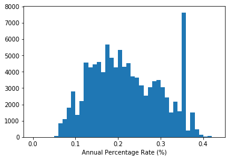

```python
plt.hist(df["BorrowerAPR"], bins=np.arange(0, df["BorrowerAPR"].max()+.01, .01));
plt.xlabel('Annual Percentage Rate (%)')
plt.show()
```

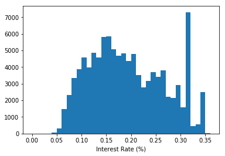

```python
plt.hist(df["BorrowerRate"], bins=np.arange(0, df["BorrowerRate"].max()+.01, .01));
plt.xlabel('Interest Rate (%)')
plt.show()
```

The main variable, BorrowerAPR, and BorrowerRate, both behave similarily (as expected). The difference between these variables is that the APR has fees and other costs included.

Next, I'll explore the **LenderYield** feature.

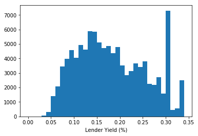

```python
plt.hist(df["LenderYield"], bins=np.arange(0, df["LenderYield"].max()+.01, .01));
plt.xlabel('Lender Yield (%)')
plt.show()
```

Again, we see a very similar distribution than BorrowerAPR and BorrowerRate.

Next, I'll explore **Term** feature.

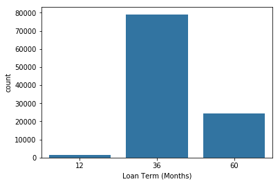

```python
base_color = sb.color_palette()[0]
sb.countplot(df["Term"], color=base_color);
plt.xlabel('Loan Term (Months)')
```

Next, I'll explore **StatedMonthlyIncome** feature.

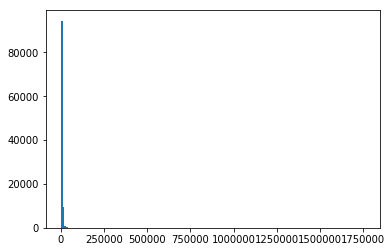

```python
plt.hist(df["StatedMonthlyIncome"], bins=np.arange(0, df["StatedMonthlyIncome"].max()+10000, 10000));
```

```python
df.query("StatedMonthlyIncome > 100000")
```

|  | ListingKey | ListingCreationDate | Term | LoanStatus | BorrowerAPR | BorrowerRate | LenderYield | StatedMonthlyIncome | Category | Occupation | EmploymentStatus | EmploymentStatusDuration |
| --- | --- | --- | --- | --- | --- | --- | --- | --- | --- | --- | --- | --- |
| 7446 | 37043512916744588463B5A | 2011-04-02 13:58:32.227 | 36 | Completed | 0.35643 | 0.3199 | 0.3099 | 4.166667e+05 | Debt Consolidation | Police Officer/Correction Officer | Employed | 183.0 |
| 16034 | 873B351262140884511D81C | 2011-04-08 21:58:21.847 | 36 | Completed | 0.35643 | 0.3199 | 0.3099 | 4.833333e+05 | Debt Consolidation | Professional | Employed | 121.0 |
| 32454 | CB0C3485937995411C24C46 | 2010-06-01 18:34:31.423 | 36 | Completed | 0.07389 | 0.0705 | 0.0605 | 1.083333e+05 | Business | Attorney | Full-time | 233.0 |
| 41518 | ABE935469654884447DAB6C | 2012-05-15 12:49:18.987 | 36 | Current | 0.33973 | 0.2999 | 0.2899 | 1.500000e+05 | Debt Consolidation | Nurse (RN) | Self-employed | 97.0 |
| 48865 | F5D13567265432980C80C7D | 2013-01-04 20:02:24.207 | 12 | Completed | 0.25785 | 0.1795 | 0.1695 | 6.185478e+05 | Business | Other | Self-employed | 117.0 |
| 49003 | F9AD3540233111834F3D8A0 | 2012-02-20 12:53:44.577 | 36 | Current | 0.35797 | 0.3177 | 0.3077 | 1.750003e+06 | Business | Professional | Self-employed | 114.0 |
| 52411 | B7FC33861182547660E2E00 | 2007-04-06 18:12:51.793 | 36 | Completed | 0.11144 | 0.1045 | 0.0995 | 1.850818e+05 | Not Available | Other | Self-employed | 8.0 |
| 52660 | BF643510331462185E12917 | 2011-03-24 14:50:00.220 | 36 | Current | 0.35643 | 0.3199 | 0.3099 | 4.666667e+05 | Home Improvement | Other | Employed | 271.0 |
| 54638 | 5D953538207426201B4AF6E | 2012-02-13 07:43:35.380 | 36 | Current | 0.24246 | 0.2049 | 0.1949 | 1.208333e+05 | Wedding | Other | Self-employed | 91.0 |
| 72303 | A6B23396838119870560CF5 | 2007-08-12 15:49:35.860 | 36 | Chargedoff | 0.20253 | 0.1952 | 0.1852 | 1.033341e+05 | Not Available | Executive | Full-time | 10.0 |
| 73823 | 3EF13599587266423B7BC76 | 2014-01-14 17:01:25.710 | 36 | Current | 0.20217 | 0.1655 | 0.1555 | 1.583333e+05 | Debt Consolidation | Attorney | Employed | 58.0 |
| 76358 | 60723558334981883FF3663 | 2012-09-11 23:56:44.900 | 36 | Current | 0.31012 | 0.2710 | 0.2610 | 2.500000e+05 | Debt Consolidation | Other | Self-employed | 137.0 |
| 102508 | 825035817683098956309D0 | 2013-06-19 06:54:27.577 | 60 | Completed | 0.20593 | 0.1819 | 0.1719 | 1.087500e+05 | Debt Consolidation | Executive | Employed | 84.0 |
| 104368 | D3AF357238727540198D36B | 2013-02-20 19:23:37.430 | 36 | Current | 0.22712 | 0.1899 | 0.1799 | 3.944000e+05 | Other | Other | Employed | 173.0 |

Since there are only a few rows with very high values, I am going to set limits to the histogram to get a better visual.

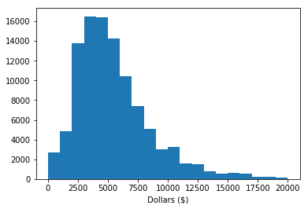

```python
plt.hist(df["StatedMonthlyIncome"], bins=np.arange(0, 20000+1000, 1000));
plt.xlabel("Dollars ($)")
```

As expected, the StatedMonthlyIncome is right skewed.

Next, I'll explore **EmploymentStatusDuration** and **EmploymentStatus**

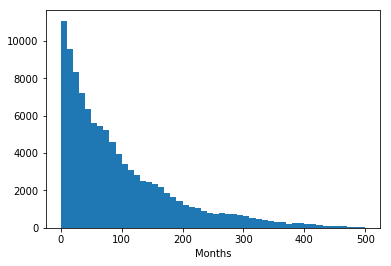

```python
plt.hist(df["EmploymentStatusDuration"], bins=np.arange(0, 500+10, 10));
plt.xlabel("Months")
```

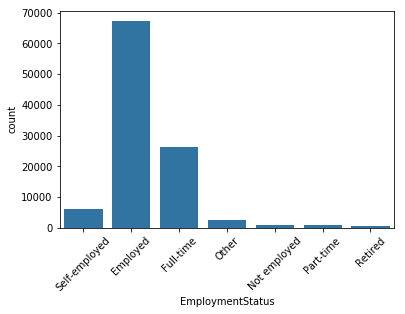

```python
sb.countplot(data=df, x="EmploymentStatus", color=base_color)
plt.xticks(rotation=45)
```

Next, I'll explore **LoanStatus**.

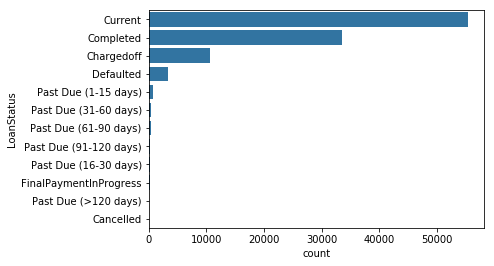

```python
LoanStatus_order = df['LoanStatus'].value_counts().index
sb.countplot(data=df, y="LoanStatus", color=base_color, order=LoanStatus_order)
```

```python
df.query("LoanStatus == 'Defaulted'")["LoanStatus"].count() / df["LoanStatus"].count()
```

```
0.03134733533361909
```

Most loans are either currently active or completed. Most Past Due loans are past by only a few days. The default rate is 3.1%.

Next, I'll explore **Category**

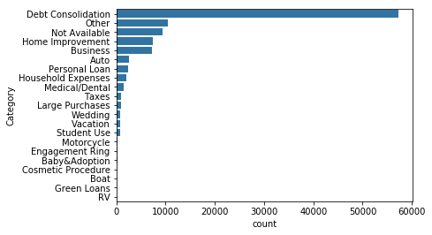

```python
cat_order = df['Category'].value_counts().index
sb.countplot(data=df, y="Category", color=base_color, order=cat_order)
```

Most Loans are for Debt Consolidation, followed by Other, Not Available, Home Improvement, and Business.

Next, I'll explore **Occupation**.

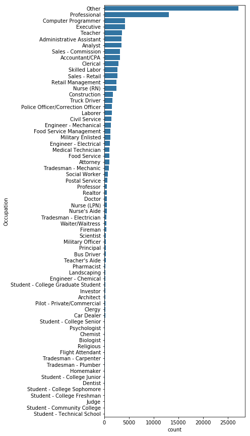

```python
occup_order = df['Occupation'].value_counts().index
fig, ax = plt.subplots(figsize=(5,15))
sb.countplot(ax=ax, data=df, y="Occupation", color=base_color, order=occup_order)
```

There are thousands of different jobs available in the world. It makes sense that the most selected option is "Other". I found it insterested that one of the most common occupations teachers. It's going to be interesting to see how occupation and income are related.

Finally, I am going to explore **ListingCreationDate**.

```python
years_data = df.groupby(df["ListingCreationDate"].dt.year).count()
```

```python
y = years_data["ListingCreationDate"]
x = years_data["ListingCreationDate"].index
```

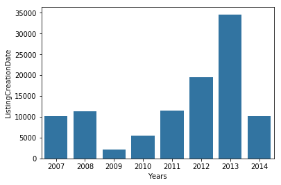

```python
sb.barplot(x=x, y=y, color=base_color)
plt.xlabel("Years")
```

```python
df["ListingCreationDate"].max()
```

```
Timestamp('2014-03-10 12:20:53.760000')
```

Loans declined heavily in 2009, and then started growing until they peaked in 2013. From context, my hypothesis is that the 2009 decline in loans is related to the financial crisis of 2008. In the graph, 2014 appears to show a decline. However, upon closer inspection we can see that its related to the end of the dataset. 2014 is not a full year, with the last loan ending in March.

## Bivariate Exploration

To start off with, I want to look at the pairwise correlations present between features in the data.

```python
numeric_vars = ["BorrowerAPR", "BorrowerRate", "LenderYield", "StatedMonthlyIncome", "EmploymentStatusDuration"]
categoric_vars = ["LoanStatus", "Category", "Occupation", "EmploymentStatus", "Term"]
```

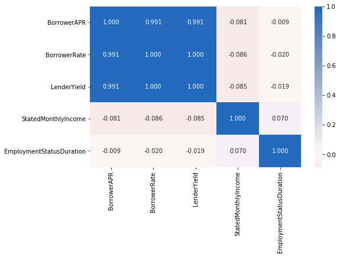

```python
# correlation plot
plt.figure(figsize = [8, 5])
sb.heatmap(df[numeric_vars].corr(), annot = True, fmt = '.3f',
           cmap = 'vlag_r', center = 0)
plt.show()
```

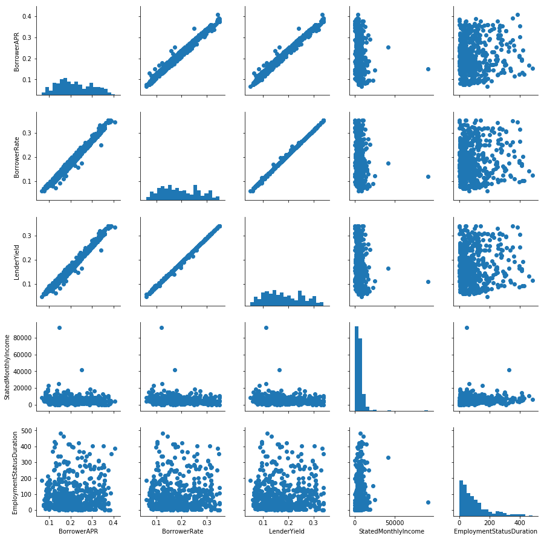

```python
samples = np.random.choice(df.shape[0], 500, replace = False)
loan_samp = df.loc[samples,:]

g = sb.PairGrid(data = loan_samp, vars = numeric_vars)
g = g.map_diag(plt.hist, bins = 20);
g.map_offdiag(plt.scatter)
```

There is a high correlation between BorrowerAPR, BorrowerRate and LenderYield. That was expected. However, the other variables had little to none correlation. I am going to have to make a deeper exploration to figure out relationships.

I am going to explore Categorical variables next.

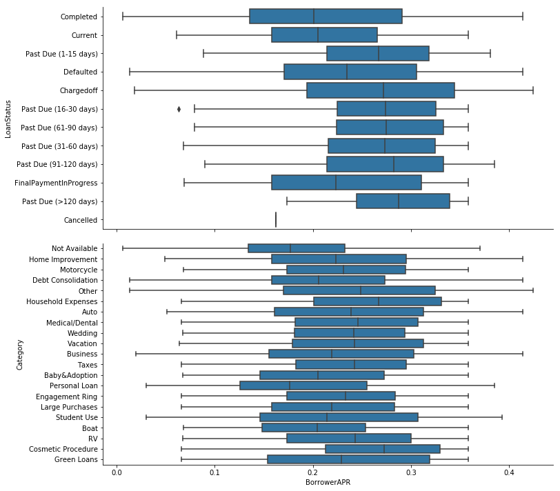

```python
def boxgrid(x, y, **kwargs):
    sb.boxplot(x, y, color = base_color)

plt.figure(figsize = [30, 30])
g = sb.PairGrid(data=df, x_vars = ['BorrowerAPR'], y_vars = ["LoanStatus", "Category"],
                size = 5, aspect = 2)
g.map(boxgrid)
plt.show();
```

I am going to try a barplot to see the BorrowerAPR means more clearly.

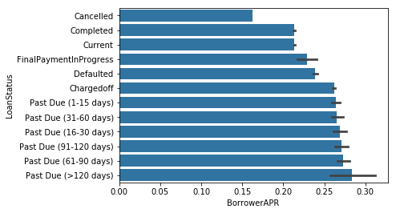

```python
ls_order = df.groupby("LoanStatus").mean().sort_values(by="BorrowerAPR").index
sb.barplot(data=df, x='BorrowerAPR', y='LoanStatus', color=base_color, order=ls_order)
```

Above, we can better see that past due loans have a higher APR. We can also see that the variability increases in past due loans. What we don't know is if the APR is higher in those loans due to the past due fees or the interest rates. Let's explore that next.

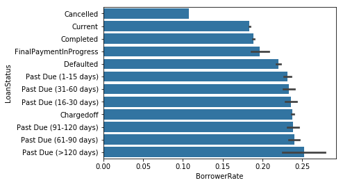

```python
ls_order = df.groupby("LoanStatus").mean().sort_values(by="BorrowerRate").index
sb.barplot(data=df, x='BorrowerRate', y='LoanStatus', color=base_color, order=ls_order)
```

We see the same relation with BorrowerRate. This means that the interest rate charged on loans that are now past due is higher than the loans that are current. This might mean that Prosper Loans was able to predict correctly those loans that would be past due and charged higher for it.

Next, I'm going to do a barplot of Category and BorrowerAPR.

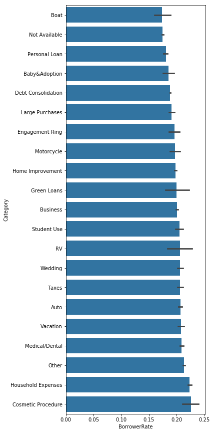

```python
cat_order = df.groupby("Category").mean().sort_values(by="BorrowerRate").index
fig, ax = plt.subplots(figsize=(5,15))
sb.barplot(data=df, ax=ax, x='BorrowerRate', y='Category', color=base_color, order=cat_order)
```

I was not expecting that the average loan APR for buying a boat would be the lowest category, and loans like Auto are one of the highest. Buying a boat being a less frequent and niche market than buying a car, I was expecting the opposite result. One hypothesis for why this happened is that people who buy boats have more money or financial stability and that warrants a lower APR. We could test this by seeing how much income people who have boats have vs the rest. **I am going to test this on the Multivariate part of the document.**

Next, I will explore the relationship between Occupation and APR.

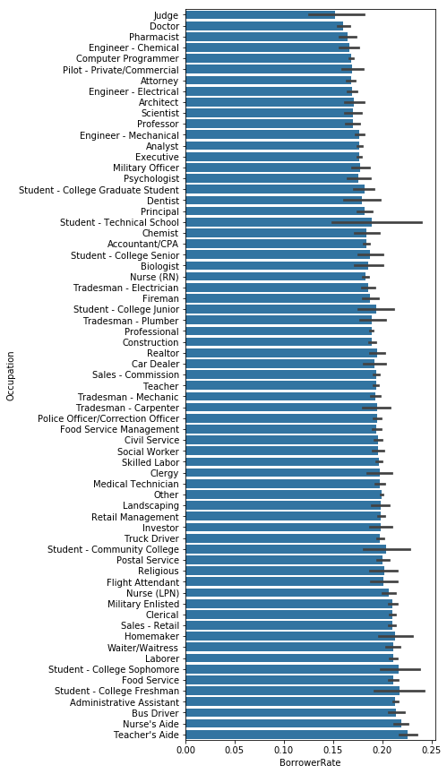

```python
Occ_order = df.groupby("Occupation").mean().sort_values(by="BorrowerAPR").index
fig, ax = plt.subplots(figsize=(5,15))
sb.barplot(data=df, ax=ax, x='BorrowerRate', y='Occupation', color=base_color, order=Occ_order)
```

Judges and doctors have the lowest APRs, although judges have more variability. I want to see how this compares to the order of occupation by earnings.

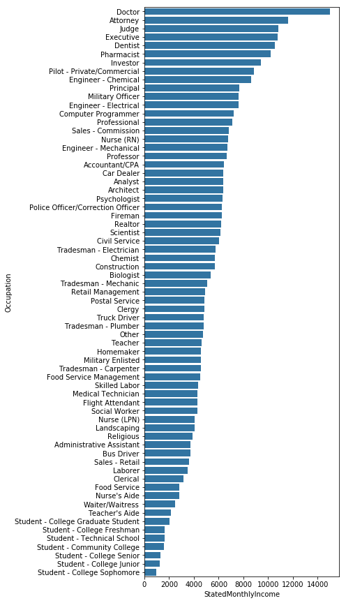

```python
x = df.groupby('Occupation').mean().sort_values(by="StatedMonthlyIncome", ascending=False)["StatedMonthlyIncome"]
y = df.groupby('Occupation').mean().sort_values(by="StatedMonthlyIncome", ascending=False)["StatedMonthlyIncome"].index
fig, ax = plt.subplots(figsize=(5,15))
sb.barplot(ax=ax, data=df, y=y, x=x, color=base_color)
```

Doctors have the biggest incomes, while students have the lowest incomes. Doctors have one of the lowest APRs as well.

Even though StatedMonthlyIncome isn't highly correlated to BorrowerAPR, I want to see if there's a difference between the top 5 earners vs the bottom 5 earners. There might be a bias towards jobs.

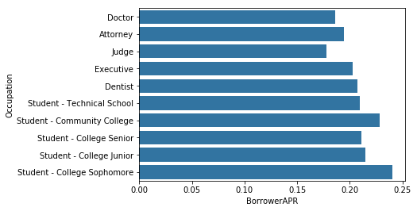

```python
Occupation_earnings = df.groupby('Occupation').mean().sort_values(by="StatedMonthlyIncome", ascending=False)
x = Occupation_earnings[:5]["BorrowerAPR"]
y = Occupation_earnings[:5]["BorrowerAPR"].index
x1= Occupation_earnings[-5:]["BorrowerAPR"]
y1 = Occupation_earnings[-5:]["BorrowerAPR"].index

x = x.append(x1)
y = y.append(y1)

sb.barplot(data=Occupation_earnings, x=x, y=y, color=base_color)
```

We can see a slight increase. It's not very big.

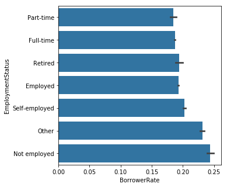

```python
status_order = df.groupby("EmploymentStatus").mean().sort_values(by="BorrowerAPR").index
fig, ax = plt.subplots(figsize=(5,5))
sb.barplot(data=df, ax=ax, x='BorrowerRate', y='EmploymentStatus', color=base_color, order=status_order)
```

As we would expect, unemployed people have the highest BorrowerAPR on average. However, I didn't expect people working Part-time to have a slighly lower APR than full-time and employed.

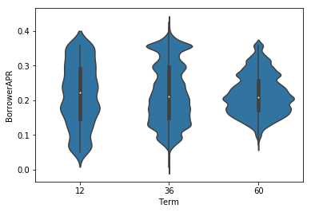

```python
sb.violinplot(data=df, x="Term", y="BorrowerAPR", color=base_color)
```

Another interestinging thing to explore is employment status and earnings.

```python
Employment_earnings = df.groupby("EmploymentStatus").mean()
```

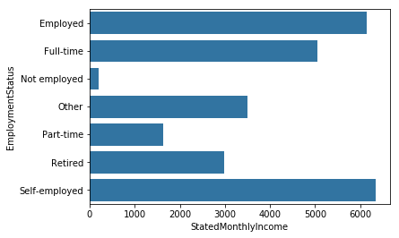

```python
x= Employment_earnings["StatedMonthlyIncome"]
y = Employment_earnings["StatedMonthlyIncome"].index

sb.barplot(data=Employment_earnings, x=x, y=y, color=base_color)
```

Employed and self-employed have very similar monthly incomes.

## Multivariate Exploration

I want to explore how the different varaibles play in affecting the APRs of the loans.

For example, we saw before that loans for boats had a lower APR than other types of loans. One hypothesis was that Boat loan borrowers had a higher salary. Let's compare this.

```python
df["Boat"] = "Others"
index = df.query("Category == 'Boat'").index
df.at[index, "Boat"] = "Boat"
```

```
[(0, 100000)]
```

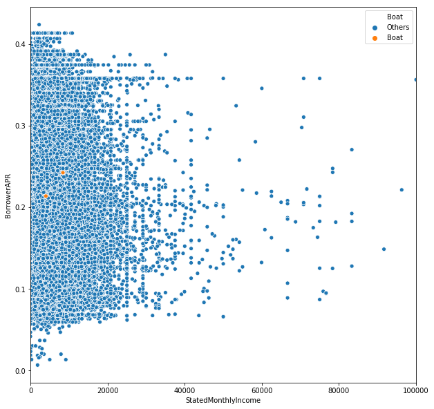

```python
fig, ax = plt.subplots(figsize=(10,10))
g = sb.scatterplot(data=df, ax=ax, y='BorrowerAPR', x='StatedMonthlyIncome', hue='Boat')
plt.legend(loc='best')
g.set(xlim=(0, 100000))
```

Boat loan borrowers clearly don't have a specially high income. Our assumption was wrong.

The most popular loan category was debt consolidation. I am going to explore how debt consolidation loans differ from the rest based on APRs and Income.

```python
df["Debt_con"] = "Others"
index = df.query("Category == 'Debt Consolidation'").index
df.at[index, "Debt_con"] = "Debt Consolidation"
```

```
[(0, 100000)]
```

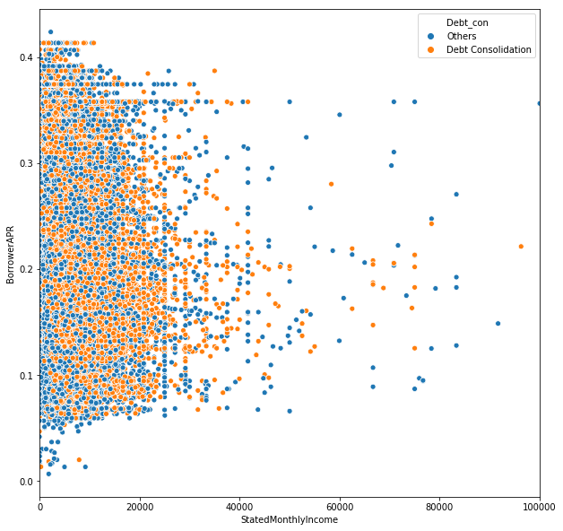

```python
fig, ax = plt.subplots(figsize=(10,10))
g = sb.scatterplot(data=df, ax=ax, y='BorrowerAPR', x='StatedMonthlyIncome', hue='Debt_con')
plt.legend(loc='best')
g.set(xlim=(0, 100000))
```

We can see that debt consolidation loans are very similar than the rest. There's no clear difference in terms of these two features: APRs and Income.

One of the highest earners and one of the lowest APR occupations are Doctors. Let's see how doctors compare to the rest in terms of APRs and Income.

```python
df["Doctors"] = "Others"
index = df.query("Occupation == 'Doctor'").index
df.at[index, "Doctors"] = "Doctors"
```

```
[(0, 100000)]
```

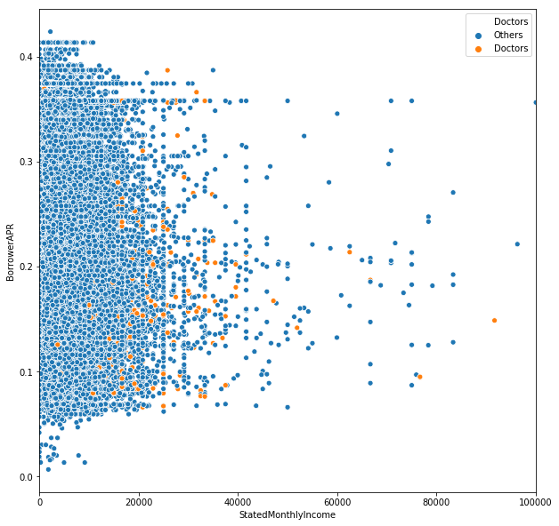

```python
fig, ax = plt.subplots(figsize=(10,10))
g = sb.scatterplot(data=df, ax=ax, y='BorrowerAPR', x='StatedMonthlyIncome', hue='Doctors')
plt.legend(loc='best')
g.set(xlim=(0, 100000))
```

While we can see that doctors tend to be higher earners than average, their APR is still dispersed across the range.

```
[(0, 100000)]
```

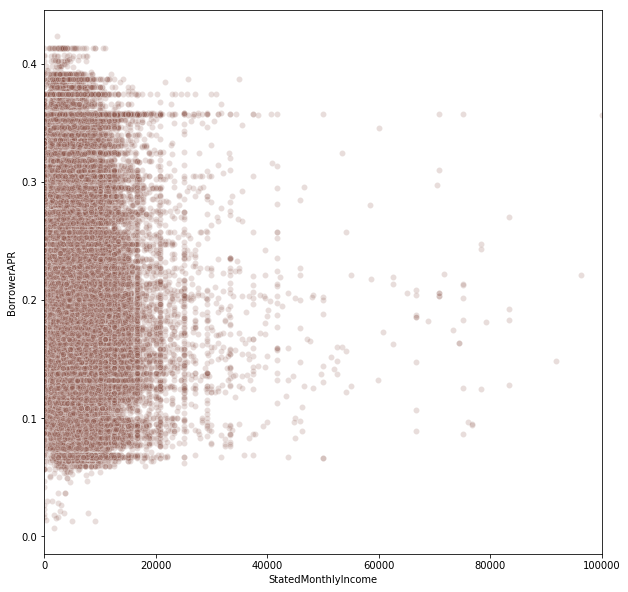

```python
fig, ax = plt.subplots(figsize=(10,10))

g = sb.scatterplot(data=df, ax=ax, y='BorrowerAPR', x='StatedMonthlyIncome', color = sb.color_palette()[5], alpha=1/5)
g.set(xlim=(0, 100000))
```

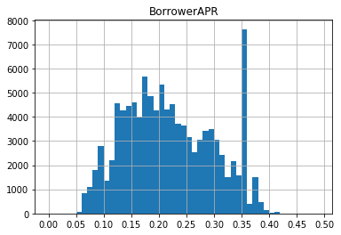

```python
df.hist("BorrowerAPR", bins=np.arange(0, 0.5, 0.01));
plt.xticks([0, 0.05, 0.1, 0.15, 0.2, 0.25, 0.3, 0.35, 0.4, 0.45, 0.5]);
```

```python
df["BorrowerAPR"].value_counts()
```

```
0.35797    3671
0.35643    1644
0.37453    1259
0.30532     902
0.29510     747
0.35356     694
0.15833     639
0.24246     604
0.24758     601
0.12528     559
0.17359     549
0.15324     536
0.27462     534
0.27285     506
0.13799     469
0.25781     444
0.12691     440
0.26528     430
0.20462     420
0.15629     412
0.23318     411
0.11296     409
0.34621     406
0.19501     403
0.20200     395
0.30564     395
0.29537     391
0.17522     362
0.21434     357
0.31032     354
           ...
0.15085       1
0.06814       1
0.13373       1
0.29117       1
0.13327       1
0.18607       1
0.15378       1
0.14837       1
0.26369       1
0.09057       1
0.14583       1
0.29794       1
0.11896       1
0.30150       1
0.15690       1
0.35946       1
0.31516       1
0.25094       1
0.22710       1
0.23088       1
0.06535       1
0.24104       1
0.16036       1
0.33458       1
0.16987       1
0.37214       1
0.13767       1
0.17331       1
0.31235       1
0.24672       1
Name: BorrowerAPR, Length: 5993, dtype: int64
```

```python
second_peak = df.query("BorrowerAPR > 0.35 & BorrowerAPR < 0.36")
second_peak.describe()
```

|  | BorrowerAPR | BorrowerRate | LenderYield | StatedMonthlyIncome | EmploymentStatusDuration |
| --- | --- | --- | --- | --- | --- |
| count | 7630.000000 | 7630.000000 | 7630.000000 | 7.630000e+03 | 7630.000000 |
| mean | 0.356583 | 0.317603 | 0.307599 | 5.013945e+03 | 93.828571 |
| std | 0.002109 | 0.008355 | 0.008349 | 2.222468e+04 | 94.355452 |
| min | 0.350020 | 0.257600 | 0.247600 | 0.000000e+00 | 0.000000 |
| 25% | 0.356430 | 0.317700 | 0.307700 | 2.500000e+03 | 24.000000 |
| 50% | 0.357970 | 0.317700 | 0.307700 | 3.915917e+03 | 64.000000 |
| 75% | 0.357970 | 0.319900 | 0.309900 | 5.833333e+03 | 134.000000 |
| max | 0.359610 | 0.350000 | 0.340000 | 1.750003e+06 | 732.000000 |

```python
df.describe()
```

|  | BorrowerAPR | BorrowerRate | LenderYield | StatedMonthlyIncome | EmploymentStatusDuration |
| --- | --- | --- | --- | --- | --- |
| count | 104985.000000 | 104985.000000 | 104985.000000 | 1.049850e+05 | 104985.000000 |
| mean | 0.220309 | 0.193128 | 0.183004 | 5.695439e+03 | 96.213173 |
| std | 0.081087 | 0.075360 | 0.075127 | 7.648746e+03 | 93.758935 |
| min | 0.006530 | 0.000000 | -0.010000 | 0.000000e+00 | 0.000000 |
| 25% | 0.157130 | 0.133400 | 0.123400 | 3.333333e+03 | 26.000000 |
| 50% | 0.210510 | 0.184000 | 0.173000 | 4.777417e+03 | 67.000000 |
| 75% | 0.285740 | 0.251100 | 0.241100 | 6.916667e+03 | 137.000000 |
| max | 0.423950 | 0.360000 | 0.340000 | 1.750003e+06 | 755.000000 |

At first glance, it looks like loans on the second peak ~0.35 APR have been in their job for less time and have a lower income than the rest of the dataset.

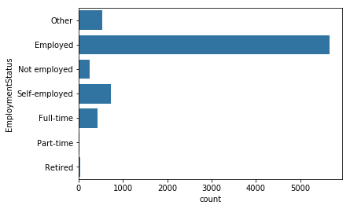

```python
sb.countplot(data=second_peak, y="EmploymentStatus", color=base_color)
```

Most people on the peak are employed.

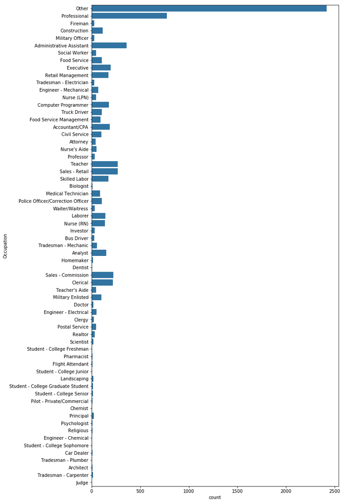

```python
fig, ax = plt.subplots(figsize=(10,20))
sb.countplot(ax=ax, data=second_peak, y="Occupation", color=base_color)
```

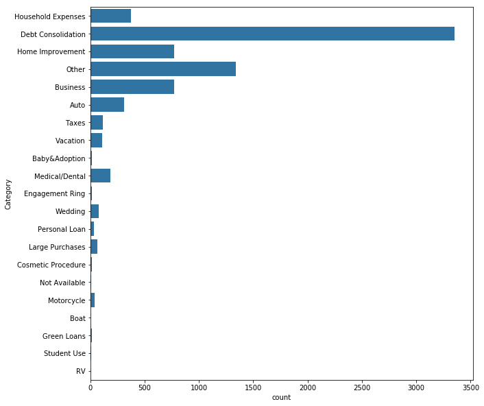

```python
fig, ax = plt.subplots(figsize=(10,10))
sb.countplot(ax=ax, data=second_peak, y="Category", color=base_color)
```

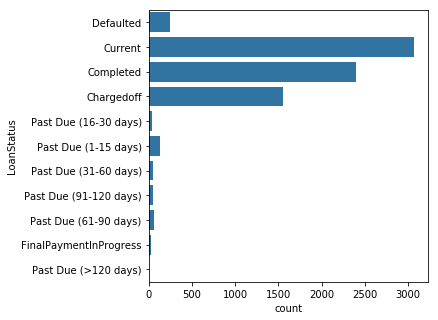

```python
fig, ax = plt.subplots(figsize=(5,5))
sb.countplot(ax=ax, data=second_peak, y="LoanStatus", color=base_color)
```

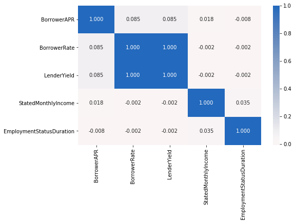

```python
# correlation plot
plt.figure(figsize = [8, 5])
sb.heatmap(second_peak[numeric_vars].corr(), annot = True, fmt = '.3f',
           cmap = 'vlag_r', center = 0)
plt.show()
```

One big difference in the second_peak data is that APR is not correlated with BorrowerRate and LenderYield. This is strange and unexpected. I will see correlations between this featrues.

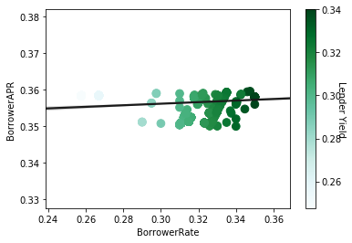

```python
points = plt.scatter(second_peak["BorrowerRate"], second_peak["BorrowerAPR"],
                     c=second_peak["LenderYield"], s=75, cmap="BuGn")
cbar = plt.colorbar(points)
cbar.ax.set_ylabel('Lender Yield', rotation=270)
sb.regplot(data=second_peak, x='BorrowerRate', y='BorrowerAPR', scatter=False, color=".1")
```

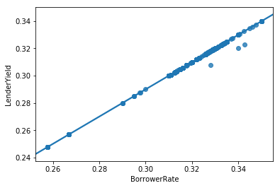

```python
sb.regplot(data=second_peak, x='BorrowerRate', y='LenderYield')
```

There's still a high correlation between BorrowerRate and LenderYield, but APRs have no relationship. Let's see how the difference between APRs and BorrowerRate behave.

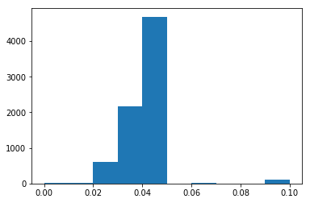

```python
diff_second_peak = second_peak["BorrowerAPR"] - second_peak["BorrowerRate"]
plt.hist(x=diff_second_peak, bins=np.arange(0, 0.1+0.01,0.01));
```

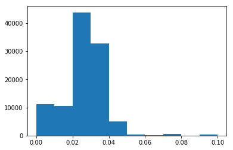

```python
diff_total = df["BorrowerAPR"] - df["BorrowerRate"]
plt.hist(x=diff_total, bins=np.arange(0, 0.1+0.01,0.01));
```

The second peak loans seem to have a higher cost of fees. The difference between APRs and Rates are higher in the second peak vs the total dataset. This may explain why the APR doesn't correlate with the Rates in this part of the dataset.